# Quantifying the Loudness War

The [Loudness War](https://en.wikipedia.org/wiki/Loudness_war) is the trend of increasing loudness levels in recorded music.

I tested this assumption as part of my project in the [Visual Data Science](https://www.cg.tuwien.ac.at/courses/2020W/VisDataScience/VU) of my Data Science Masters' at the Technical University of Vienna.

Below, I present a comprehensive report detailing my findings:

As a data source, I am using Yamac Eren Ay's [Spotify Dataset 1921-2020, 600k+ Tracks](https://www.kaggle.com/datasets/yamaerenay/spotify-dataset-19212020-600k-tracks) dataset from kaggle. I used the older 160k tracks version dataset in the past. This version is not available anymore, so I updated it to the new version. The findings remain similar.

```python
import numpy as np
import pandas as pd
import matplotlib.pyplot as plt
import seaborn as sns
```

## Read dataset from csv and clean it.

During this phase, I extract the 'year' from the 'release_date' column. It's important to note that the 'release_date' column has varying formats, either 'YYYY-MM-DD' or just 'YYYY'.

The loudness is measured in dB.

```python
# load data from csv, selecting only 'release_date' and 'loudness' columns
df = pd.read_csv('data/tracks.csv', usecols=['release_date', 'loudness'])
```

```python
# convert 'release_date' to datetime and extract year
df['year'] = pd.to_datetime(df['release_date'], errors='coerce').dt.year
```

```python
# drop rows with missing 'year' or 'loudness' values
df.dropna(subset=['year', 'loudness'], inplace=True)
```

```python
nr_of_years = df['year'].max() - df['year'].min() + 1
```

## Visualize the features

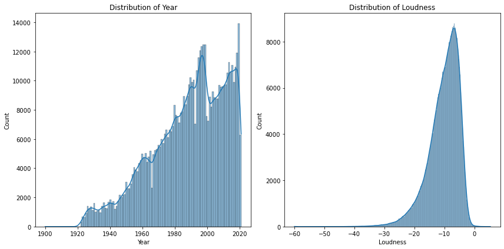

```python
f, axes = plt.subplots(1, 2, figsize=(12, 6), sharex=False)

sns.histplot(df["year"], ax=axes[0], kde=True, bins=nr_of_years)
axes[0].set_title('Distribution of Year')
axes[0].set_xlabel('Year')

sns.histplot(df["loudness"], ax=axes[1], kde=True)
axes[1].set_title('Distribution of Loudness')
axes[1].set_xlabel('Loudness')


plt.tight_layout()
plt.show()
```

The dataset has very few records before and around 1920. To determine the exact amount of data points, let's count the number of values in this range.

```python
df[df['year'] <= 1925]['year'].value_counts().sort_index()
```

```
1900      1
1922    294
1923    657
1924    633
1925    903
Name: year, dtype: int64
```

Starting at 1922, we have enough data for our investigation.

```python
df.query('year >= 1922', inplace=True)
```

Next, I'll visualize the data using a scatterplot. Given the vast number of data points and the discrete nature of the 'year' column, I've added a random horizontal jitter within a range of +/- 0.5 to better discern the data density.

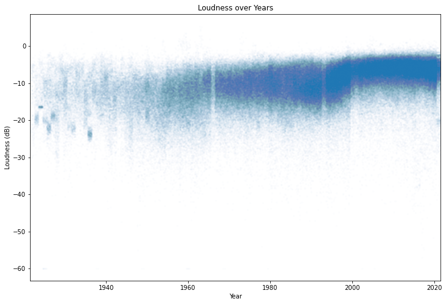

```python
plt.figure(figsize=(12, 8))

# create new year column with added random jitter, for better scatterplot visualization
jitter = np.random.uniform(-0.5, 0.5, size=len(df))
df['year_jittered'] = df['year'] + jitter

sns.scatterplot(data=df, x='year_jittered', y='loudness', marker='.', alpha=.01)

plt.xlim(df['year_jittered'].min(), df['year_jittered'].max())

plt.title('Loudness over Years')
plt.xlabel('Year')
plt.ylabel('Loudness (dB)')

plt.show()
```

## Statistical Analysis

In order to analyse the relationship between the year and loudness, I decided to use a spearman rank correlation coefficient. This test does not require a normally distributed dataset.

```python
from scipy.stats import spearmanr

# compute Spearman rank correlation between 'year' and 'loudness'
coef, p_value = spearmanr(df['year'], df['loudness'])

print(f"Spearman rank correlation coefficient: {coef:.3f}")
print(f"P-value: {p_value}")
```

```
Spearman rank correlation coefficient: 0.496
P-value: 0.0
```

With a coefficient of ~0.5 and a p-value below the threshold of the scipy function, there is a clear positive correlation between the year and the loudness.

## Fitting a Linear Model

In a next step I want to quantify the change per year by fitting a linear model and getting the slope.

```python
import statsmodels.formula.api as smf

# Fit a linear regression model to predict 'loudness' based on 'year'

results = smf.ols('loudness ~ year', data=df).fit()

print(results.summary())
```

```
                            OLS Regression Results
==============================================================================
Dep. Variable:               loudness   R-squared:                       0.200
Model:                            OLS   Adj. R-squared:                  0.200
Method:                 Least Squares   F-statistic:                 1.465e+05
Date:                Tue, 19 Sep 2023   Prob (F-statistic):               0.00
Time:                        17:55:24   Log-Likelihood:            -1.7216e+06
No. Observations:              586671   AIC:                         3.443e+06
Df Residuals:                  586669   BIC:                         3.443e+06
Df Model:                           1
Covariance Type:            nonrobust
==============================================================================
                 coef    std err          t      P>|t|      [0.025      0.975]
------------------------------------------------------------------------------
Intercept   -208.3732      0.518   -402.485      0.000    -209.388    -207.358
year           0.0997      0.000    382.797      0.000       0.099       0.100
==============================================================================
Omnibus:                   156590.967   Durbin-Watson:                   1.641
Prob(Omnibus):                  0.000   Jarque-Bera (JB):           595003.391
Skew:                          -1.298   Prob(JB):                         0.00
Kurtosis:                       7.195   Cond. No.                     1.73e+05
==============================================================================

Notes:
[1] Standard Errors assume that the covariance matrix of the errors is correctly specified.
[2] The condition number is large, 1.73e+05. This might indicate that there are
strong multicollinearity or other numerical problems.
```

```python
intercept = results.params['Intercept']
slope = results.params['year']

print(f"Slope of loudness over years: {slope:.4f}")
```

```
Slope of loudness over years: 0.0997
```

## Result

The loudness of the tracks in this dataset increases by **0.1 dB per year**.

To visualize this, I added the regression line to the scatterplot of before.

(Note that the blue dot in the legend does not exactly represent a data point in the visualization. An exact representation of this size and transparency would barely be visible.)

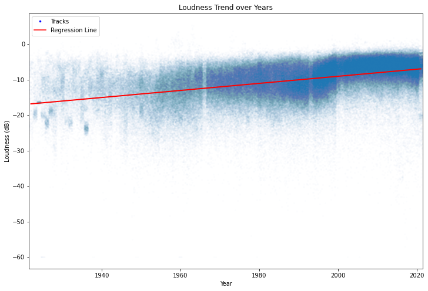

```python
import matplotlib.lines as mlines

plt.figure(figsize=(12, 8))

sns.scatterplot(data=df, x='year_jittered', y='loudness', marker='.', alpha=.01, label='Tracks')

# plot regression line to visualize the trend in loudness over the years
year_start, year_end = df['year'].min(), df['year'].max()
plt.plot([year_start, year_end], [intercept + slope * year_start, intercept + slope * year_end], linewidth=2, color='red', label='Regression Line')

plt.xlim(df['year_jittered'].min(), df['year_jittered'].max())

plt.title('Loudness Trend over Years')
plt.xlabel('Year')
plt.ylabel('Loudness (dB)')

legend_handle = [mlines.Line2D([], [], color='blue', marker='.', linestyle='None', markersize=5, label='Tracks'),
                 mlines.Line2D([], [], color='red', linestyle='-', markersize=10, label='Regression Line')]
plt.legend(handles=legend_handle, loc='upper left')

plt.show()
```